# CHAPTER A23

# 変位法による解析

**JOSEPH A. WOLF, Jr.**

## A23.1 はじめに

変位法または剛性法 (1-4)* は、力ではなく変位を独立変数（および未知数）として使用する構造解析の手順である。ここで適用されるように、変位法は有限要素を用いた構造モデリングと組み合わせて使用される。使用される代表的な要素は、棒および梁セグメント、薄板およびプレートセクション、ならびに円錐シェル台頭部である。未知の変位の数は、選択された要素の数とモデリングに使用される洗練度または詳細度によって決定される。選択された節点の変位によって与えられる記述が、構造の変形を表現するのに十分であると仮定される。より良い表現が必要な場合は、より多くの節点、したがってより多くの要素によって構造をモデル化することができる。実際の荷重は、仮想仕事の原理を用いて計算された一組の節点力に置き換えられる。

* カッコ内の数字は章末の参考文献を示す。

もちろん、構造の挙動を記述するために両方の方法を使用することができる。たとえば、力法の欠点のいくつかは、プログラムされた自動余剰選択機構や「構造切断機（structure cutters）」によって克服できる。解析機能を効率的に遂行するためには、技術者は両方の方法に習熟していなければならない。

変位法の定式化は、大型電子デジタルコンピュータの利用に促されて、過去15年間に完成された。1950年には、10個または12個の独立した座標を含むシステムの解は、卓上計算機を使って手作業で行う解析者にとって膨大な労力を意味していた。現在のコンピュータプログラムは、数千の座標で表される構造を日常的に処理している。この能力と速度の向上により、構造解析は予備的またはパラメータ計算のために設計プロセスで使用できるようになっている。オンライングラフィックス機器を使用すれば、設計技術者はコンピュータの計算中に直接情報を送受信することにより、設計を操作することさえできる。

なお、余談ではあるが、第A11章のたわみ角法（Moment Distribution Method）、第A12章の傾斜たわみ角法（Slope Deflection Method）、および第A6章とA15章の逐次修正法（Method of Successive Corrections）は、すべて構造解析の変位法の例である。これらの各方法では、変位が独立変数として採用され、これらは荷重された構造の釣り合いを達成するために調整される。調整は、人工的な制約の系統的な緩和（たわみ角法および逐次修正法）として現れるか、あるいは連立方程式の解（傾斜たわみ角法）によって一挙に数学的に行われる。後者のアプローチ（連立方程式の解）は、本質的にここで従うものであり、解は通常、行列の反転またはガウスの消去法によって得られる。

## A23.2 構造座標

構造の各微粒子のたわみを考慮することは不可能である。代わりに、システムの変形した形状を大まかに（しかし十分に有用な方法で）記述する有限個の量によってシステムを特徴付ける。これらの量は座標と呼ばれ、離散座標と分布座標の2種類がある。どちらの種類も、現実の単純化されたモデリングを伴う。

離散座標は、有限個の点の変位の観点から主要な変形モードを特定できる場合に使用される。

たとえば、梁要素では、変形形状が要素の端部の運動によって十分に記述できると仮定する。各端部には、線形変位の3成分と回転の3成分の計6つの運動成分がある（Fig. A23.1）。したがって、要素の変形は、端部のたわみと回転を定義することによって可能な程度にのみ記述される。この記述は、要素に沿って外力が作用しない場合には、明らかに完全に適切である。要素に沿って荷重が作用し、より詳細な情報が必要な場合は、内部位置に節点を定義して、各部材を実質的に2つ以上の要素に分割することができる。

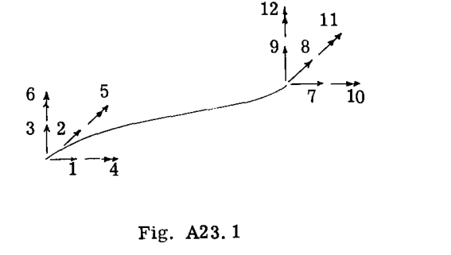

Fig. A23.1

分布座標は、弾性部材のすべての点の変位を同時に近似する空間関数である。たとえば、単純支持梁がある場合、Fig. A23.2に示す $\Phi$ 関数を使用してそれを記述できる。

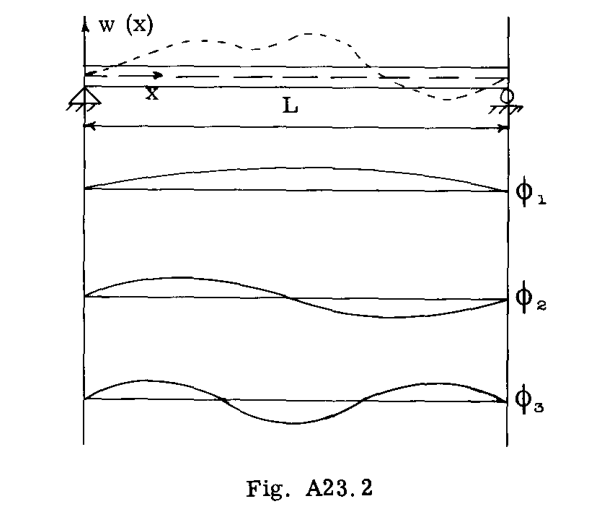

Fig. A23.2

したがって、

$$w(x) = u_1
\phi_1(x) + u_2
\phi_2(x) + u_3
\phi_3(x) + \dots
\quad ---\text{(1)}$$

ここでも、実用的な理由から、使用される級数は有限の範囲であるため、正確な表現を与えることはできない。

要素の集合が結合してシステムを構成するとき、システムを特徴付け、それを単なる要素の積み重ねと区別する特定の結合条件または拘束条件および境界条件が存在する。

これらの概念を明確にするために、変形が図の平面内に制限されていると仮定される単純なポータルフレームの例を考える（Fig. A23.3）。

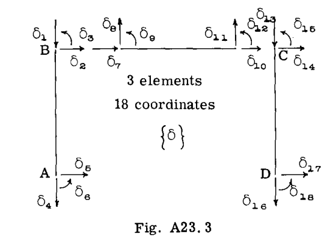

Fig. A23.3

拘束条件と境界条件は以下の通りである：

1. 点AおよびDにおける固定端条件（たわみなし）。
2. 点BおよびCにおける運動学的拘束条件。これにより、点Bにおいて要素1と2のたわみと回転が同じになり、点Cにおいて要素2と3のたわみと回転が同じになる。

重複する座標を排除すると、Fig. A23.4に示すように、6つのシステム座標が残る。要素座標は $\delta$ で表され、構造システム座標は $u$ で表される。（使用されている記号は一般にRubinstein、文献1および2のものに従っている。したがって、理論をより詳細に学習することに関心のある読者は、新しい用語集を学ぶ必要はない。）

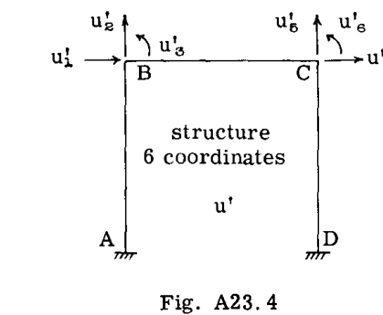

Fig. A23.4

実用的な問題として、運動学的拘束条件はシステム剛性行列をコンパイルするときに考慮される。境界条件も同様に処理されるか、あるいは必要であれば、その後のステップで一度に適用することができる。多くの構造問題において、さらなる単純化が一般的である。要素内の軸荷重による応力とひずみは、曲げ荷重によって生じるものよりもはるかに小さいことが多い。そのような場合、フレーム部材は伸縮しないと仮定することができる。したがって、Fig. A23.4において、 $u_2' = u_5' = 0$ 、および $u_4' = u_1'$ とすることができ、このレベルのモデリングの抽象化に対して3つの一般化座標が残る。Fig. A23.5は、これらの一般化座標に対応する構造変形パターンを示している。

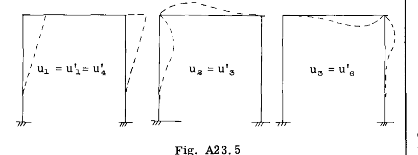

Fig. A23.5

## A23.3 変位法の理論的基礎

与えられた構造の静的解析を行うには、外力 $\{F\}$ と節点の一般化たわみ $\{u\}$ との関係を導き出さなければならない。特に、たわみは独立変数として扱われるため、次のような方程式を導き出すことを目指す。

$$\{F\} = [K]\{u\}
\quad ---\text{(2)}$$

ここで、行列 $[K]$ はシステム剛性行列である。（この章全体を通じて、行列表記が採用されている。使用されている記号は、特に断りのない限り、付録Aで定義されている。）

剛性行列の要素に物理的な意味を与えるために、 $u$ の1つ、たとえば $u_s$ に単位たわみを与える実験を考えることができる。 $[K]$ の第 $s$ 列の要素は、構造にこのたわみ形状を与えるために必要な力に等しい。または同様に、他のすべての座標を固定したまま座標 $s$ を単位量だけたわませたときに、各節点で発生する力である。この第 $s$ 列の中で、要素 $K_{rs}$ は、その変形形状において座標 $r$ で発生する力である。システム剛性行列は、後で示されるように、個々の要素剛性行列を足し合わせることによって構築される。

構造要素の剛性特性は、関心のある特定の構成に弾性理論を適用することによって定義される。さまざまな方法が使用されてきた。ここでは、弾性棒の場合は仮想仕事の原理、梁の場合は曲げの微分方程式を用いて手順を説明する。要素の力と変位はそれぞれ $P$ と $\delta$ で表され、構造システムの節点における力と変位（それぞれ $F$ と $u$ で表される）と区別される。

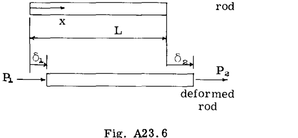

Fig. A23.6

端部で軸方向変位 $\delta_1$ および $\delta_2$ を受ける均一な弾性棒について、任意の断面 $x$ における変位は次のように与えられる。

$$\delta = \delta_1 + (\delta_2 - \delta_1)\frac{x}{L}
\quad ---\text{(3)}$$

全軸ひずみは一様であり、次のように与えられる。

$$e_x = \frac{1}{L}(\delta_2 - \delta_1)
\quad ---\text{(4)}$$

棒が軸方向応力（荷重）に加えて $T$ 度の温度上昇を受ける場合、全ひずみ $e_x$ は弾性ひずみ $\epsilon_x$ と熱ひずみ $\alpha T$ の和に等しくなる。弾性ひずみは、ひずみエネルギーを計算するために必要な量であり、すなわち、

$$\epsilon_x = \frac{1}{L}(\delta_2 - \delta_1) - \alpha T
\quad ---\text{(5)}$$

ひずみの観点からA7.1ページの式2を書き直し、弾性棒に対して $\sigma_x A = S$ および $\epsilon_x E = \sigma_x$ を代入すると、次式が得られる。

$$U = \frac{AE L}{2}\epsilon_x^2 = \frac{AE}{2L}[(\delta_2 - \delta_1) - \alpha T L]^2
\quad ---\text{(6)}$$

仮想仕事の原理（A7.5ページの式14）を使用すると、

$$P_r = \frac{\partial U}{\partial \delta_r}
\quad ---\text{(7)}$$

したがって、

$$P_1 = \frac{\partial U}{\partial \delta_1} = -\frac{AE}{L}[(\delta_2 - \delta_1) - \alpha T L]
\quad ---\text{(8a)}$$

および

$$P_2 = \frac{\partial U}{\partial \delta_2} = \frac{AE}{L}[(\delta_2 - \delta_1) - \alpha T L]
\quad ---\text{(8b)}$$

ここで、力は $\delta_1$ および $\delta_2$ と同じ正の方向性を持つ。この情報は、次のように行列形式で表すことができる。

$$\begin{Bmatrix} P_1 \\ P_2 \end{Bmatrix} = \frac{AE}{L}\begin{bmatrix} 1 & -1 \\ -1 & 1 \end{bmatrix} \begin{Bmatrix} \delta_1 \\ \delta_2 \end{Bmatrix} + AE\alpha T\begin{Bmatrix} 1 \\ -1 \end{Bmatrix}
\quad ---\text{(9)}$$

そして、正方行列を弾性棒の軸方向たわみに対する要素剛性行列 $[k]$ として認識する。 $[k]$ の要素は、仮想仕事の原理を書き直すことによって直接計算することもできる。 $K_{rs}$ の定義を思い出すと、これは座標 $\delta_s$ における単位たわみあたりの力 $P_r$ である。したがって、

$$k_{rs} = \frac{\partial P_r}{\partial \delta_s} = \frac{\partial^2 U}{\partial \delta_r \partial \delta_s}
\quad ---\text{(10)}$$

この結果は、剛性行列の対称性 $k_{rs} = k_{sr}$ を示しているため、興味深いものである。

第二の例として、梁のたわみの微分方程式の解を使用して、梁の剛性行列を導き出す。Fig. A23.7における単位端部たわみ $\delta_3 = 1$ を考慮する。

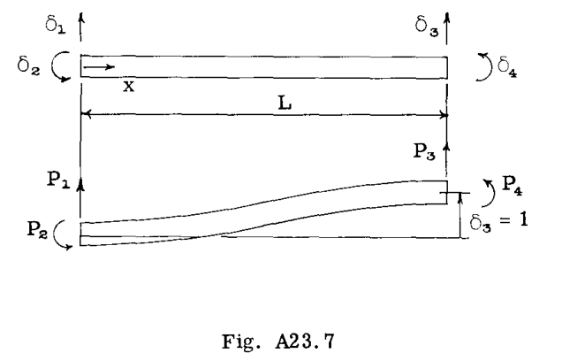

Fig. A23.7

梁の微分方程式は次の通りである（A17.2ページ）。

$$EI\frac{d^2w}{dx^2} = M(x) = P_1 x - P_2
\quad ---\text{(11)}$$

ここで、以下の境界条件に従う。

$$\left. \begin{aligned} w &= \delta_1 = 0 \\ \frac{dw}{dx} &= \delta_2 = 0 \end{aligned} \right\} \text{ at } x = 0
\quad ---\text{(12a)}$$

$$\left. \begin{aligned} w &= \delta_3 = 1 \\ \frac{dw}{dx} &= \delta_4 = 0 \end{aligned} \right\} \text{ at } x = L
\quad ---\text{(12b)}$$

$x$ について2回積分すると、結果は次のようになる。

$$EIw = \frac{P_1 x^3}{6} - \frac{P_2 x^2}{2} + C_1 x + C_2
\quad ---\text{(13)}$$

$x = 0$ における境界条件を使用すると、 $C_1 = C_2 = 0$ であることがわかる。 $x = L$ における条件は、未知数 $P_1$ と $P_2$ に関する2つの方程式を提供する。

$$\frac{P_1 L^3}{6} - \frac{P_2 L^2}{2} = EI
\quad ---\text{(14a)}$$

$$\frac{P_1 L^2}{2} - P_2 L = 0
\quad ---\text{(14b)}$$

である。これらの結果は、剛性行列の第3列を確立する。残りの項も同様の手順で求められ、結果は次のようになる。

$$\begin{Bmatrix} P_1 \\ P_2 \\ P_3 \\ P_4 \end{Bmatrix} = \frac{EI}{L^3}\begin{bmatrix} 12 & 6L & -12 & 6L \\ 6L & 4L^2 & -6L & 2L^2 \\ -12 & -6L & 12 & -6L \\ 6L & 2L^2 & -6L & 4L^2 \end{bmatrix} \begin{Bmatrix} \delta_1 \\ \delta_2 \\ \delta_3 \\ \delta_4 \end{Bmatrix}
\quad ---\text{(15)}$$

重ね合わせの方法は、剛性係数の代替的な導出を提供する（Fig. A23.8を参照）。

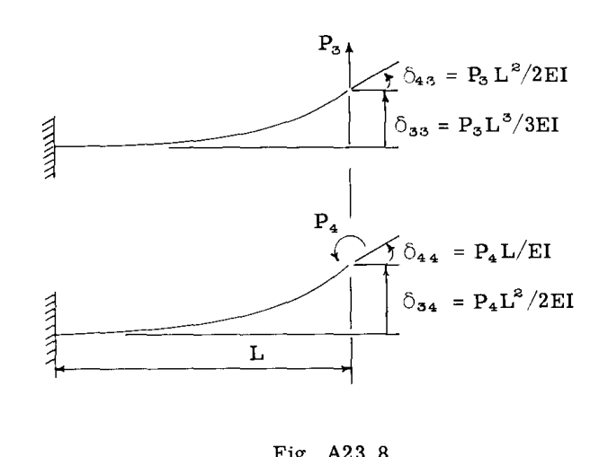

Fig. A23.8

境界条件を使用すると、

$$\delta_3 = \delta_{33} + \delta_{34} = \frac{P_3 L^3}{3EI} + \frac{P_4 L^2}{2EI} = 1
\quad ---\text{(16a)}$$

$$\delta_4 = \delta_{43} + \delta_{44} = \frac{P_3 L^2}{2EI} + \frac{P_4 L}{EI} = 0
\quad ---\text{(16b)}$$

以前と同様に、

$$P_3 = \frac{12EI}{L^3}$$

および

$$P_4 = -\frac{6EI}{L^2}$$

が得られる。

この場合、 $P_1$ と $P_2$ は静的釣り合いから決定される。残りの係数も同様にして決定される。剛性行列の対称性に現れる相反性も、結果 $\delta_{43}/P_3 = \delta_{34}/P_4 = L^2/2EI$ によって示されており、これはマクスウェル・ベッチの相反定理の再表明である。

## A23.4 要素特性の図表化

各ケースにおいて、一般化力は、示されている関連する一般化変位座標と同じ正の方向を持つものとする。

### A. 軸力を伴う棒

$$\begin{Bmatrix} P_1 \\ P_2 \end{Bmatrix} = \frac{AE}{L}\begin{bmatrix} 1 & -1 \\ -1 & 1 \end{bmatrix} \begin{Bmatrix} \delta_1 \\ \delta_2 \end{Bmatrix}$$

### B. ねじりを受ける棒

$$\begin{Bmatrix} P_1 \\ P_2 \end{Bmatrix} = \frac{GJ}{L}\begin{bmatrix} 1 & -1 \\ -1 & 1 \end{bmatrix} \begin{Bmatrix} \delta_1 \\ \delta_2 \end{Bmatrix}$$

### C. 梁

$$\begin{Bmatrix} P_1 \\ P_2 \\ P_3 \\ P_4 \end{Bmatrix} = \frac{EI}{L^3}\begin{bmatrix} 12 & 6L & -12 & 6L \\ 6L & 4L^2 & -6L & 2L^2 \\ -12 & -6L & 12 & -6L \\ 6L & 2L^2 & -6L & 4L^2
\end{bmatrix} \begin{Bmatrix} \delta_1 \\ \delta_2 \\ \delta_3 \\ \delta_4 \end{Bmatrix}$$

### D. テーパー梁

$$\begin{Bmatrix} P_1 \\ P_2 \\ P_3 \\ P_4 \end{Bmatrix} = \frac{3EI_j}{2DL^3}\begin{bmatrix} A & BL & -A & CL \\ BL & 2L^2\phi_{ii} & -BL & L^2\phi_{ij} \\ -A & -BL & A & -CL \\ CL & L^2\phi_{ij} & -CL & 2L^2\phi_{jj} \end{bmatrix} \begin{Bmatrix} \delta_1 \\ \delta_2 \\ \delta_3 \\ \delta_4 \end{Bmatrix}$$

ここで、

$$\begin{aligned}
A &= 2(\phi_{ii} + \phi_{jj} + \phi_{ij}) \\
B &= 2\phi_{ii} + \phi_{ij} \\
C &= \phi_{ij} + 2\phi_{jj} \\
D &= \phi_{ii}\phi_{jj} - \frac{1}{4}\phi_{ij}^2
\end{aligned}$$

であり、 $\phi_{ii}$ 、 $\phi_{ij}$ 、および $\phi_{jj}$ は、比 $A_i/A_j$ ではなく比 $I_i/I_j$ の関数として Fig. A7.34c に与えられている。これらの関数は、慣性モーメントが線形に変化する梁のケースに対して導出されたものであることに注意されたい。

### E. 線形変化する軸力を伴う棒

$$\begin{Bmatrix} P_1 \\ P_2 \\ P_3 \end{Bmatrix} = \frac{2AE}{L^3}\begin{bmatrix} 6 & -3L & -3L \\ -3L & 2L^2 & L^2 \\ -3L & L^2 & 2L^2 \end{bmatrix} \begin{Bmatrix} \delta_1 \\ \delta_2 \\ \delta_3 \end{Bmatrix}$$

せん断流 $P_1$ とそれに関連するたわみ $\delta_1$ は、それぞれポンド/インチおよび平方インチの単位を持つことに注意されたい（A7.5節参照）。 $\delta_1$ に物理的な解釈を与えることは困難であるが、 $P_1$ と $\delta_1$ の積は予想通りひずみエネルギーの単位を持つ。演習として、読者はこのケースの柔軟性行列（A7.10節）が剛性行列の逆行列であることを示すことができる。

### F. せん断パネル

$$\begin{Bmatrix} P_1 \\ P_2 \\ P_3 \\ P_4 \end{Bmatrix} = \frac{Gt}{ab}\begin{bmatrix} 1 & 1 & -1 & -1 \\ 1 & 1 & -1 & -1 \\ -1 & -1 & 1 & 1 \\ -1 & -1 & 1 & 1 \end{bmatrix} \begin{Bmatrix} \delta_1 \\ \delta_2 \\ \delta_3 \\ \delta_4 \end{Bmatrix}$$

この場合も、単位は「力」と「変位」に対してそれぞれポンド/インチおよび平方インチである。ここでは独立した座標が1つしかなく、これは加えられた力のせん断作用によるコーナーの1つにおける角度の変化によって物理的に表されることに注意されたい。

### G. その他の要素

本節では、最も単純な要素のみを示した。幸いなことに、多くの実用的な問題は、要素の包括的なカタログが別の章を簡単に埋めることができるため、この情報を使用して解決できる。広く応用されている他の要素としては、膜力を伴う二次元要素（三角形、正方形、および台形要素を含む）、二次元プレート曲げ要素（三角形、正方形、および台形要素を含む）、薄肉シェル要素（円錐台および複曲率要素を含む）、軸対称厚肉シェル要素（さまざまな断面形状を持つリング要素を含む）、および一般的な三次元要素（四面体および六面体要素を含む）がある。これらおよびその他の要素は、構造解析者によって開発および完成されつつある。要素間の適合性の欠如は、より複雑な有限要素の重要な欠点であり、多くの継続的な研究の動機となっている。詳細については、この分野の豊富な文献を参照されたい。

## A23.5 座標の変換

元の座標（または要素特性を定義するのに便利だった座標）と、一般化座標または独立座標との間で変位を変換する必要がよくある。この目的のために、幾何学を使用して次のように与えられる変換行列 $[\beta]$ を定義する。

$$\{\delta\} = [\beta]\{u\}
\quad ---\text{(17)}$$

Figs. A23.3 と A23.5 のポータルフレームについて、目視により次式が得られる。

$$\begin{Bmatrix} \delta_1 \\ \delta_2 \\ \delta_3 \\ \delta_4 \\ \delta_5 \\ \delta_6 \\ \hline \delta_7 \\ \delta_8 \\ \delta_9 \\ \delta_{10} \\ \delta_{11} \\ \delta_{12} \\ \hline \delta_{13} \\ \delta_{14} \\ \delta_{15} \\ \delta_{16} \\ \delta_{17} \\ \delta_{18} \end{Bmatrix} = \begin{bmatrix} 0 & 0 & 0 \\ 1 & 0 & 0 \\ 0 & 1 & 0 \\ 0 & 0 & 0 \\ 0 & 0 & 0 \\ 0 & 0 & 0 \\ \hline 1 & 0 & 0 \\ 0 & 0 & 0 \\ 0 & 1 & 0 \\ 1 & 0 & 0 \\ 0 & 0 & 0 \\ 0 & 0 & 1 \\ \hline 0 & 0 & 0 \\ 1 & 0 & 0 \\ 0 & 0 & 1 \\ 0 & 0 & 0 \\ 0 & 0 & 0 \\ 0 & 0 & 0 \end{bmatrix} \begin{Bmatrix} u_1 \\ u_2 \\ u_3 \end{Bmatrix}
\quad ---\text{(18)}$$

便利のために、システム $[\beta]$ 行列は、示されているように要素 $[\beta_e]$ 行列に分割することができる。これらのより小さな行列は、後述するように、要素特性を変換するために一度に1つずつ使用することができる。

同様に、力をシステムからシステムへ変換したい。これを行うための方法は、仮想仕事の式から導き出される。

$u$ 座標系に関連する力 $F$ を考える。仮想変位 $\{\Delta u\}$ のセットに対して、仮想仕事は以下の通りである*。

$$\Delta W = \{F\}^T \{\Delta u\}
\quad ---\text{(19)}$$

$\delta$ システムの場合、

$$\Delta W = \{P\}^T \{\Delta \delta\}
\quad ---\text{(20)}$$

また、座標変換から導出される適合条件式もある。

$$\{\Delta \delta\} = [\beta]\{\Delta u\}
\quad ---\text{(21)}$$

ここで、仮想仕事はスカラーであり、 $P$ と $F$ は釣り合っており、 $\delta$ と $u$ は適合しているため、仮想仕事はどちらのシステムでも同じである。

したがって、

$$\{F\}^T \{\Delta u\} = \{P\}^T \{\Delta \delta\} = \{P\}^T [\beta] \{\Delta u\}
\quad ---\text{(22)}$$

* $\{\}^T$ および $[\ ]^T$ は、それぞれ列行列および長方形行列の転置を表す。

そして、 $\Delta u$ は独立であるため、

$$\{F\}^T = \{P\}^T [\beta] \text{ または } \{F\} = [\beta]^T \{P\}
\quad ---\text{(23)}$$

となり、これが望ましい関係式である。

次に、剛性行列と柔軟性行列がどのようにある座標セットから別の座標セットに変換されるかを問う。適切な公式は、要素のひずみエネルギーの式から導き出すことができる。

$$U = \frac{1}{2} \{\delta\}^T [k] \{\delta\} = \frac{1}{2} \{u\}^T [K] \{u\}
\quad ---\text{(24)}$$

$\{\delta\} = [\beta]\{u\}$ であるため、最初の式は次のように書き換えることができる。

$$U = \frac{1}{2} \{u\}^T [\beta]^T [k] [\beta] \{u\}
\quad ---\text{(25)}$$

そして、 $u$ は独立であるため、

$$[K] = [\beta]^T [k] [\beta]
\quad ---\text{(26)}$$

柔軟性行列（要素およびシステムに対してそれぞれ $[a]$ および $[a]$ で表される）を変換するには、さらなる結果が必要である。釣り合いから、要素力 $\{P\}$ と外力節点力 $\{F\}$ の間の関係を見つけることができる。

$$\{P\} = [b] \{F\}
\quad ---\text{(27)}$$

これは $[b]$ を定義する（不静定構造については以下を参照）。要素のひずみエネルギーを書き出すと、

$$U = \frac{1}{2} \{P\}^T [a] \{P\} = \frac{1}{2} \{F\}^T [a] \{F\}
\quad ---\text{(28)}$$

式27を使用して $\{P\}$ を代入し、最終的な式を導き出すことができる。

$$[a] = [b]^T [a] [b]
\quad ---\text{(29)}$$

ここでは、 $\{F\}$ 力が独立であるという事実を使用している。

多くの場合、それらの座標におけるゼロの適用力に関連付けられている変位が $\{u\}$ に存在する。以下のように置く。

$$\{u\} = \begin{Bmatrix} u^* \\ \hline u^0 \end{Bmatrix}
\quad ---\text{(30)}$$

ここで、 $\{u^*\}$ は適用力 $\{F^*\}$ を持つ座標上の変位であり、 $\{u^0\}$ はゼロ値の適用力を持つ座標上の変位である。

その場合、

$$\begin{Bmatrix} F^* \\ \hline 0 \end{Bmatrix} = \begin{bmatrix} K_{11} & K_{12} \\ K_{21} & K_{22} \end{bmatrix} \begin{Bmatrix} u^* \\ \hline u^0 \end{Bmatrix}
\quad ---\text{(31)}$$

したがって、

$$\{F^*\} = [K_{11}] \{u^*\} + [K_{12}] \{u^0\}
\quad ---\text{(32a)}$$

および

$$\{0\} = [K_{21}] \{u^*\} + [K_{22}] \{u^0\}
\quad ---\text{(32b)}$$

または

$$\{u^0\} = -[K_{22}]^{-1} [K_{21}] \{u^*\}
\quad ---\text{(33)}$$

式32aに代入すると、

$$\{F^*\} = \left( [K_{11}] - [K_{12}] [K_{22}]^{-1} [K_{21}] \right) \{u^*\}
\quad ---\text{(34)}$$

したがって、縮小された剛性行列を定義することができる。

$$[K^*] = [K_{11}] - [K_{12}] [K_{22}]^{-1} [K_{21}]
\quad ---\text{(35)}$$

そして、任意の与えられた問題で $\{u^*\}$ が分かれば、 $\{u^0\}$ は式33からすぐに求めることができる。

同様に、柔軟性法は、逆の状況が当てはまる静的に不静定な構造、すなわち力が（余剰の）ゼロ変位に関連付けられている場合に有用である。

構造内の余剰力の数に対応する自己釣り合い力のセットを含めるために、 $\{F\}$ を拡張する。ポータルフレームの場合、Fig. A23.9に示すように3つの余剰力がある。余剰力における変位は実際にはゼロである。

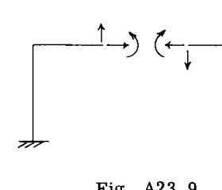

Fig. A23.9

したがって、次式が得られる。

$$\begin{Bmatrix} u^* \\ \hline 0 \end{Bmatrix} = \begin{bmatrix} a_{11} & a_{12} \\ a_{21} & a_{22}
\end{bmatrix} \begin{Bmatrix} F^* \\ \hline F^0 \end{Bmatrix}
\quad ---\text{(36)}$$

そして、ゼロ力のケースとの類似性により、

$$\{u^*\} = [a^*] \{F^*\}
\quad ---\text{(37)}$$

ここで、

$$[a^*] = [a_{11}] - [a_{12}] [a_{22}]^{-1} [a_{21}]
\quad ---\text{(38)}$$

柔軟性法は、静的に不静定な構造のシステム力と要素力の間の関係を導き出す際にも有用である。余剰力を含む拡張された力のセットに対して、静的釣り合いに基づいて次のように書くことができる。

$$\{P\} = \begin{bmatrix} b^* & b^0 \end{bmatrix} \begin{Bmatrix} F^* \\ \hline F^0 \end{Bmatrix}
\quad ---\text{(39)}$$

この時点では、 $\{F^0\}$ は未知である。

しかし、式36から、

$$[a_{21}] \{F^*\} + [a_{22}] \{F^0\} = \{0\}$$

または

$$\{F^0\} = -[a_{22}]^{-1} [a_{21}] \{F^*\}
\quad ---\text{(40)}$$

したがって、

$$\{P\} = \left( [b^*] - [b^0] [a_{22}]^{-1} [a_{21}] \right) \{F^*\}
\quad ---\text{(41)}$$

となり、これが望ましい変換である。力、変位、剛性、および/または柔軟性に関する情報をある座標系から別の座標系に変換する方法を見てきた。次の課題は、これらの方法を適用して要素特性からシステム特性に変換することである。いくつかの導出を繰り返すのではなく、結果を以下に図表化する。

### Table A23.1

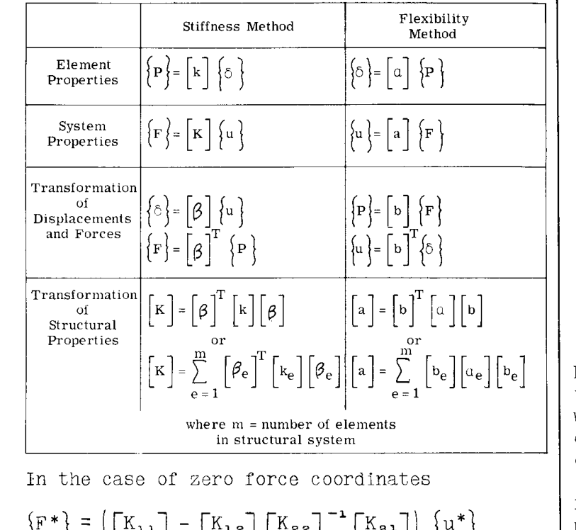

Table A23.1

#### ゼロ力座標の場合

$$\begin{aligned}
\{F^*\} &= \left( [K_{11}] - [K_{12}] [K_{22}]^{-1} [K_{21}] \right) \{u^*\} \\
&= [K^*] \{u^*\}
\end{aligned}$$

#### ゼロ変位（余剰）座標の場合

$$\begin{aligned}
\{u^*\} &= \left( [a_{11}] - [a_{12}] [a_{22}]^{-1} [a_{21}] \right) \{F^*\} \\
&= [a^*] \{F^*\}
\end{aligned}$$

### 例題 1

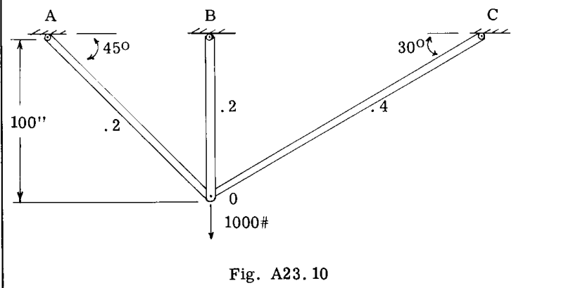

Fig. A23.10

選択された座標を Fig. A23.11 に示す。

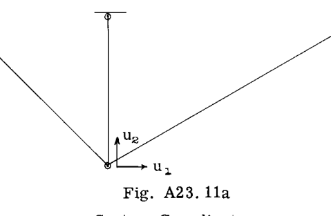

Fig. A23.11a

**システム座標**

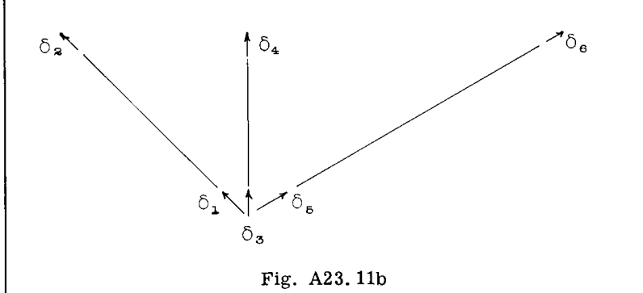

Fig. A23.11b

**要素座標**

境界点 A, B, C におけるシステム座標を含めることもできたが、境界条件を適用したときに脱落したはずである。簡単のために、これらの座標は解析の最初に削除されている。システム剛性行列を構築するには、各要素からの寄与を見つける必要がある。たとえば、要素 OC の場合、要素剛性は次のように与えられる。

$$[k_{oc}] = \frac{A_{oc}E}{L_{oc}} \begin{bmatrix} 1 & -1 \\ -1 & 1 \end{bmatrix} = \frac{E}{10^3} \begin{bmatrix} 2 & -2 \\ -2 & 2 \end{bmatrix}
\quad ---\text{(42)}$$

要素座標からシステム座標への変換は、 $\{\delta_{oc}\} = [\beta_{oc}] \{u\}$ によって与えられる。または、Figs. A23.10 と A23.11 から、

$$\begin{Bmatrix} \delta_5 \\ \delta_6 \end{Bmatrix} = \begin{bmatrix} 0.866 & 0.500 \\ 0 & 0 \end{bmatrix} \begin{Bmatrix} u_1 \\ u_2 \end{Bmatrix}
\quad ---\text{(43)}$$

したがって、要素 OC はシステム剛性行列に次の項を寄与する。

$$[K_{oc}] = [\beta_{oc}]^T [k_{oc}] [\beta_{oc}] = \frac{E}{10^3} \begin{bmatrix} 1.5 & 0.866 \\ 0.866 & 0.5 \end{bmatrix}
\quad ---\text{(44)}$$

同様に、要素 OA および OB について以下の情報をまとめることができる。

### Table A23.2

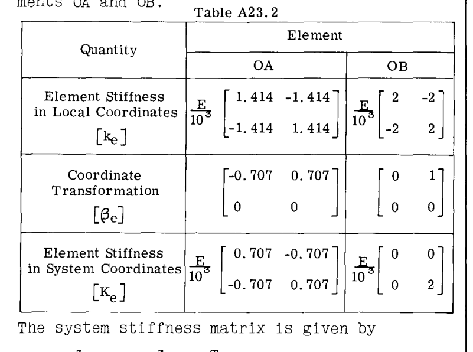

Table A23.2

システム剛性行列は次式で与えられる。

$$[K] = \sum_{e=1}^{3} [K_e] = \sum_{e=1}^{3} [\beta_e]^T [k_e] [\beta_e]
\quad ---\text{(45)}$$

または

$$[K] = \frac{E}{10^3} \begin{bmatrix} 2.207 & 0.159 \\ 0.159 & 3.207 \end{bmatrix}
\quad ---\text{(46)}$$

これは、システム力とたわみの間の関係を提供する。

### 例題 2

一様な要素特性を仮定し、軸変形を無視して、Fig. A23.12a のポータルフレームのシステム剛性行列を構築する。要素座標を Fig. A23.12b に示し、要素剛性行列は A23.4 節のケース C によって与えられる。

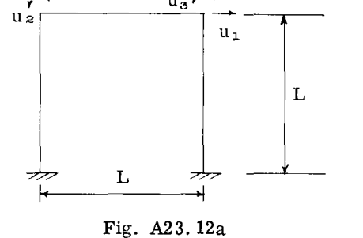

Fig. A23.12a

**システム座標**

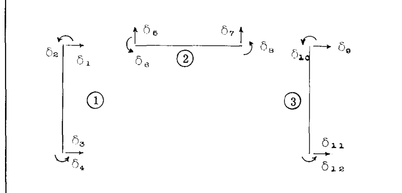

Fig. A23.12b

**要素座標**

一般に、 $[K] = [\beta]^T [k] [\beta]$ であり、ここで、

$$[\beta] = \begin{bmatrix} \beta_1 \\ \beta_2 \\ \beta_3 \end{bmatrix} = \begin{bmatrix} 1 & 0 & 0 \\ 0 & 1 & 0 \\ 0 & 0 & 0 \\ 0 & 0 & 0 \\ \hline 0 & 0 & 0 \\ 0 & 1 & 0 \\ 0 & 0 & 0 \\ 0 & 0 & 1 \\ \hline 1 & 0 & 0 \\ 0 & 0 & 1 \\ 0 & 0 & 0 \\ 0 & 0 & 0 \end{bmatrix}
\quad ---\text{(47)}$$

および

$$[k] = \begin{bmatrix} k_1 & 0 & 0 \\ 0 & k_2 & 0 \\ 0 & 0 & k_3 \end{bmatrix}
\quad ---\text{(48)}$$

であり、各 $[k_e]$ は A23.4 節のケース C で与えられた結果に等しい。

## A23.6 変位と応力の計算

与えられた力の適用から生じるたわみを解くための方法はいくつかある。最も直接的な方法は、剛性行列を反転することであり（詳細は付録 A を参照）、その結果、

$$\{u\} = [K]^{-1} \{F\}
\quad ---\text{(50)}$$

$F_1 = 0$ および $F_2 = -1000\text{ lb.}$ が与えられると、水平たわみ $u_1 = 22500/E\text{ インチ}$ 、垂直たわみ $u_2 = -312900/E\text{ インチ}$ を得る。最後のステップは、要素力を計算することである。これを行うには、変換行列 $[\beta]$ または $[\beta_e]$ を使用して要素たわみを求めなければならない。部材 OC について、式 43 を使用すると、

$$\begin{Bmatrix} \delta_5 \\ \delta_6 \end{Bmatrix} = \begin{bmatrix} 0.866 & 0.500 \\ 0 & 0 \end{bmatrix} \begin{Bmatrix} \frac{22500}{E} \\ \frac{-312900}{E} \end{Bmatrix} = \begin{Bmatrix} \frac{-137000}{E} \\ 0 \end{Bmatrix}
\quad ---\text{(52)}$$

および

$$\{P\} = [k]\{\delta\}$$

または

$$\begin{Bmatrix} P_5 \\ P_6 \end{Bmatrix} = \frac{E}{10^3} \begin{bmatrix} 2 & -2 \\ -2 & 2
\end{bmatrix} \begin{Bmatrix} \frac{-137000}{E} \\ 0 \end{Bmatrix} = \begin{Bmatrix} -274 \\ 274 \end{Bmatrix}
\quad ---\text{(53)}$$

したがって、部材 OC の力は $274\text{ lb.}$ の引張であり、これは 8.4 節で以前に得られた結果と一致する。同様に、部材 OA および OB の力は、それぞれ $335\text{ lb.}$ および $626\text{ lb.}$ である。

## A23.7 ガウスの消去法

数十、数百、あるいはしばしば数千の未知数の解を伴う大規模なシステムでは、行列反転法は他の手法よりも時間がかかる。基本的に、代替の解法は、消去法と反復法（5, 6）の2つのカテゴリに分けられる。

ガウスの消去法、またはコレスキー分解などのその変形は、大規模な方程式系の実用的な解決方法として広く使用されている。基本的なガウスの消去法について、ここで説明し使用する。線形方程式系を考える。

$$\begin{aligned}
C_{11}X_1 + C_{12}X_2 + C_{13}X_3 + \dots + C_{1n}X_n &= C_{1,n+1} \\
C_{21}X_1 + C_{22}X_2 + C_{23}X_3 + \dots + C_{2n}X_n &= C_{2,n+1} \\
C_{31}X_1 + C_{32}X_2 + C_{33}X_3 + \dots + C_{3n}X_n &= C_{3,n+1} \\
&\dots \\
C_{n1}X_1 + C_{n2}X_2 + C_{n3}X_3 + \dots + C_{nn}X_n &= C_{n,n+1}
\end{aligned}
\quad ---\text{(54)}$$

最初に方程式の左辺を三角化し、後続の各方程式の未知数を減らし、最終的に単一の未知数 $X_n$ を含む最終方程式を得ることで、解法を体系化したい。解法は、まず最後の未知数 $X_n$ を解き、次にこの情報を使用して $X_{n-1}$ を解く、というようにして完了する。三角化された形式では、各未知数（たとえば $X_r$ ）は、 $n \ge m > r$ である $X_m$ のみに依存する。

三角化の最初のステップは、以下を使用して、2番目の方程式およびそれ以降のすべての方程式の新しい係数を計算することである。

$$C_{ij}^{(1)} = C_{ij} - \frac{C_{i1}}{C_{11}}C_{1j}
\quad
\begin{aligned}
i &= 2, \dots, n \\
j &= 2, \dots, n+1
\end{aligned}
\quad ---\text{(55)}$$

これにより、方程式は次の形式になる。

$$\begin{aligned}
C_{11}X_1 + C_{12}X_2 + C_{13}X_3 + \dots + C_{1n}X_n &= C_{1,n+1} \\
C_{22}^{(1)}X_2 + C_{23}^{(1)}X_3 + \dots + C_{2n}^{(1)}X_n &= C_{2,n+1}^{(1)} \\
C_{32}^{(1)}X_2 + C_{33}^{(1)}X_3 + \dots + C_{3n}^{(1)}X_n &= C_{3,n+1}^{(1)} \\
&\dots \\
C_{n2}^{(1)}X_2 + C_{n3}^{(1)}X_3 + \dots + C_{nn}^{(1)}X_n &= C_{n,n+1}^{(1)}
\end{aligned}
\quad ---\text{(56)}$$

最終的な形式は次のようになる。

$$\begin{aligned}
C_{11}X_1 + C_{12}X_2 + C_{13}X_3 + \dots + C_{1n}X_n &= C_{1,n+1} \\
C_{22}^{(1)}X_2 + C_{23}^{(1)}X_3 + \dots + C_{2n}^{(1)}X_n &= C_{2,n+1}^{(1)} \\
C_{33}^{(2)}X_3 + \dots + C_{3n}^{(2)}X_n &= C_{3,n+1}^{(2)} \\
&\dots \\
C_{nn}^{(n-1)}X_n &= C_{n,n+1}^{(n-1)}
\end{aligned}$$

ここで、任意のステップにおける係数は次のように与えられる。

$$C_{ij}^{(k)} = C_{ij}^{(k-1)} - \frac{C_{ik}^{(k-1)}}{C_{kk}^{(k-1)}}C_{kj}^{(k-1)}
\quad
\begin{aligned}
k &= 1, 2, \dots, n-1 \\
j &= k+1, \dots, n+1 \\
i &= k+1, \dots, n
\end{aligned}
\quad ---\text{(58)}$$

および

$$C_{ij}^{(0)} = C_{ij}$$

後退代入は、次の記号形式をとる。

$$X_i = \frac{1}{C_{ii}^{(i-1)}} \left[ C_{i,n+1}^{(i-1)} - \sum_{j=i+1}^{n} C_{ij}^{(i-1)}X_j \right]
\quad i = n, \dots, 1
\quad ---\text{(59)}$$